# Trabalho final da disciplina

CONCEITOS ESTATISCOS PARA IA

Grupo2IA

November 30, 2018

```r
# Carregue aqui todos os pacotes utilizados
# na sua análise realizada neste arquivo fonte.

# Note que o parâmetro "echo" foi definido como FALSE neste código.
# Isso previne que o código apresente resultados formatados em HTML.
# Você deve definir  para todos os blocos de código no seu arquivo.
#require(readr)

install_missing_packages <- function(needToBeFixed = FALSE,... ) {
  # Instala pacotes caso necessario
  if ( "knitr" %in% rownames(installed.packages()) == FALSE ) { install.packages("knitr", dependencies = TRUE) }
  if ( "ggplot2" %in% rownames(installed.packages()) == FALSE ) { install.packages("ggplot2", dependencies = TRUE) }
  if ( "grid" %in% rownames(installed.packages()) == FALSE ) { install.packages("grid", dependencies = TRUE) }
  if ( "gridExtra" %in% rownames(installed.packages()) == FALSE ) { install.packages("gridExtra", dependencies = TRUE) }
  if ( "dplyr" %in% rownames(installed.packages()) == FALSE ) { install.packages("dplyr", dependencies = TRUE) }
  if ( "scales" %in% rownames(installed.packages()) == FALSE ) { install.packages('scales', dependencies = TRUE) }
  if ( "GGally" %in% rownames(installed.packages()) == FALSE ) { install.packages("GGally", dependencies = TRUE) }
  if ( "gtable" %in% rownames(installed.packages()) == FALSE ) { install.packages("gtable", dependencies = TRUE) }
  if ( "corrgram" %in% rownames(installed.packages()) == FALSE ) { install.packages("corrgram", dependencies = TRUE) }
  if ( "psych" %in% rownames(installed.packages()) == FALSE ) { install.packages("psych", dependencies = TRUE) }
  if ( "memisc" %in% rownames(installed.packages()) == FALSE ) { install.packages("memisc", dependencies = TRUE) }
  if ( "rpart" %in% rownames(installed.packages()) == FALSE ) { install.packages("rpart", dependencies = TRUE) }
  if ( "gmodels" %in% rownames(installed.packages()) == FALSE ) { install.packages("gmodels", dependencies = TRUE) }
  if ( "rpart.plot" %in% rownames(installed.packages()) == FALSE ) { install.packages("rpart.plot", dependencies = TRUE) }
  if ( "rattle" %in% rownames(installed.packages()) == FALSE ) { install.packages("rattle", dependencies = TRUE) }
}

# Instala pacotes adicionais e pacotes necessários
install_missing_packages()

library(knitr)
library(ggplot2)
library(grid)
library(gridExtra)
library(dplyr)
library(scales)
library(GGally)
library(gtable)
library(corrgram)
library(psych)
library(memisc)
library(rpart) #for trees
library(rpart.plot)
library(gmodels)
library(rattle)
```

# Análise “Análise de Vinho baseado em um Dataset fornecido”

> Alunos:

| Nome | RM |
| --- | --- |
| Augusto Cesar Ribeiro Freire | 330695 |
| Marcelo Muzilli | 331136 |
| Rafael da Silva Tomaz | 330267 |
| Renato Tavares da Silva | 330659 |

Utilizando a base de vinhos (documento anexado) e disponibilizada em aula o objetivo do trabalho é mensurar a variável “Quality” dos vinhos desta região de Portugal com as variáveis de características (composição) dos vinhos.

Algumas etapas importantes: 1. Base Reconhecimento da Base: Um descritivo do tamanho da base, quantidade de variáveis, formatos, e alguns descritivos (“achados”) sobre a base/variáveis.

```
## [1] 1599   12
```

```
## 'data.frame':    1599 obs. of  12 variables:
##  $ fixed.acidity       : Factor w/ 96 levels "10","10.1","10.2",..: 71 75 75 13 71 71 76 70 75 72 ...
##  $ volatile.acidity    : Factor w/ 143 levels "0.12","0.16",..: 77 113 89 13 77 69 57 67 53 42 ...
##  $ citric.acid         : Factor w/ 80 levels "0","0.01","0.02",..: 1 1 5 57 1 1 7 1 3 37 ...
##  $ residual.sugar      : Factor w/ 91 levels "0.9","1.2","1.3",..: 11 31 26 11 11 10 6 2 20 73 ...
##  $ chlorides           : Factor w/ 153 levels "0.012","0.034",..: 40 62 56 39 40 39 33 29 37 35 ...
##  $ free.sulfur.dioxide : Factor w/ 60 levels "1","10","11",..: 3 18 7 9 3 5 7 7 60 9 ...
##  $ total.sulfur.dioxide: Factor w/ 144 levels "10","100","101",..: 75 109 95 102 75 81 100 60 57 4 ...
##  $ density             : Factor w/ 436 levels "0.99007","0.9902",..: 343 272 288 355 343 343 240 101 272 343 ...
##  $ pH                  : Factor w/ 89 levels "2.74","2.86",..: 64 33 39 29 64 64 43 52 49 48 ...
##  $ sulphates           : Factor w/ 96 levels "0.33","0.37",..: 19 31 28 21 19 19 9 10 20 43 ...
##  $ alcohol             : Factor w/ 65 levels "10","10.0333333333333",..: 57 63 63 63 57 57 57 1 58 7 ...
##  $ quality             : int  5 5 5 6 5 5 5 7 7 5 ...
```

```
##  fixed.acidity  volatile.acidity  citric.acid   residual.sugar
##  7.2    :  67   0.6    :  47     0      : 132   2      :156
##  7.1    :  57   0.5    :  46     0.49   :  68   2.2    :131
##  7.8    :  53   0.43   :  43     0.24   :  51   1.8    :129
##  7.5    :  52   0.59   :  39     0.02   :  50   2.1    :128
##  7      :  50   0.36   :  38     0.26   :  38   1.9    :117
##  7.7    :  49   0.58   :  38     0.1    :  35   2.3    :109
##  (Other):1271   (Other):1348     (Other):1225   (Other):829
##    chlorides    free.sulfur.dioxide total.sulfur.dioxide    density
##  0.08   :  66   6      : 138        28     :  43         0.9972 :  36
##  0.074  :  55   5      : 104        24     :  36         0.9968 :  35
##  0.076  :  51   10     :  79        15     :  35         0.9976 :  35
##  0.078  :  51   15     :  78        18     :  35         0.998  :  29
##  0.084  :  49   12     :  75        23     :  34         0.9962 :  28
##  0.071  :  47   7      :  71        14     :  33         0.9978 :  26
##  (Other):1280   (Other):1054        (Other):1383         (Other):1410
##        pH         sulphates       alcohol        quality
##  3.3    :  57   0.6    :  69   9.5    : 139   Min.   :3.000
##  3.36   :  56   0.54   :  68   9.4    : 103   1st Qu.:5.000
##  3.26   :  53   0.58   :  68   9.8    :  78   Median :6.000
##  3.38   :  48   0.62   :  61   9.2    :  72   Mean   :5.636
##  3.39   :  48   0.56   :  60   10     :  67   3rd Qu.:6.000
##  3.29   :  46   0.57   :  55   10.5   :  67   Max.   :8.000
##  (Other):1291   (Other):1218   (Other):1073
```

```
## [1] 4898   12
```

```
## 'data.frame':    4898 obs. of  12 variables:
##  $ fixed.acidity       : Factor w/ 68 levels "10","10.2","10.3",..: 38 30 50 41 41 50 29 38 30 50 ...
##  $ volatile.acidity    : Factor w/ 125 levels "0.08","0.085",..: 37 43 39 29 29 39 47 37 43 27 ...
##  $ citric.acid         : Factor w/ 87 levels "0","0.01","0.02",..: 37 35 41 33 33 41 17 37 35 44 ...
##  $ residual.sugar      : Factor w/ 310 levels "0.6","0.7","0.8",..: 190 18 258 286 286 258 261 190 18 16 ...
##  $ chlorides           : Factor w/ 160 levels "0.009","0.012",..: 35 39 40 48 48 40 35 35 39 34 ...
##  $ free.sulfur.dioxide : Factor w/ 132 levels "10","101","105",..: 66 17 41 68 68 41 41 66 17 36 ...
##  $ total.sulfur.dioxide: Factor w/ 251 levels "10","100","101",..: 76 36 249 94 94 249 40 76 36 32 ...
##  $ density             : Factor w/ 890 levels "0.98711","0.98713",..: 879 472 561 602 602 561 545 879 472 454 ...
##  $ pH                  : Factor w/ 103 levels "2.72","2.74",..: 24 54 50 43 43 50 42 24 54 46 ...
##  $ sulphates           : Factor w/ 79 levels "0.22","0.23",..: 23 27 22 18 18 22 25 23 27 23 ...
##  $ alcohol             : Factor w/ 104 levels "10","10.0333333333333",..: 88 95 3 104 104 3 98 88 95 22 ...
##  $ quality             : int  6 6 6 6 6 6 6 6 6 6 ...
```

```
##  fixed.acidity  volatile.acidity  citric.acid   residual.sugar
##  6.8    : 308   0.28   : 263     0.3    : 307   1.2    : 187
##  6.6    : 290   0.24   : 253     0.28   : 282   1.4    : 184
##  6.4    : 280   0.26   : 240     0.32   : 257   1.6    : 165
##  6.9    : 241   0.25   : 231     0.34   : 225   1.3    : 147
##  6.7    : 236   0.22   : 229     0.29   : 223   1.1    : 146
##  7      : 232   0.27   : 218     0.26   : 219   1.5    : 142
##  (Other):3311   (Other):3464     (Other):3385   (Other):3927
##    chlorides    free.sulfur.dioxide total.sulfur.dioxide    density
##  0.044  : 201   29     : 160        111    :  69         0.992  :  64
##  0.036  : 200   31     : 132        113    :  61         0.9928 :  61
##  0.042  : 184   26     : 129        117    :  57         0.9932 :  53
##  0.04   : 182   35     : 129        118    :  55         0.993  :  52
##  0.046  : 181   34     : 128        114    :  54         0.9934 :  50
##  0.048  : 174   36     : 127        122    :  54         0.9938 :  49
##  (Other):3776   (Other):4093        (Other):4548         (Other):4569
##        pH         sulphates       alcohol        quality
##  3.14   : 172   0.5    : 249   9.4    : 229   Min.   :3.000
##  3.16   : 164   0.46   : 225   9.5    : 228   1st Qu.:5.000
##  3.22   : 146   0.44   : 216   9.2    : 199   Median :6.000
##  3.19   : 145   0.38   : 214   9      : 185   Mean   :5.878
##  3.18   : 138   0.42   : 181   10     : 162   3rd Qu.:6.000
##  3.2    : 137   0.48   : 179   10.5   : 160   Max.   :9.000
##  (Other):3996   (Other):3634   (Other):3735
```

> Análise exploratória de dados:

Detecção de outliers, gráficos e análise sobre os dois tipos de vinhos. Correlações entre elas (numéricas e gráficos).

> Análise Exploratória de dados - Gráficos e análise sobre o tipo de vinho

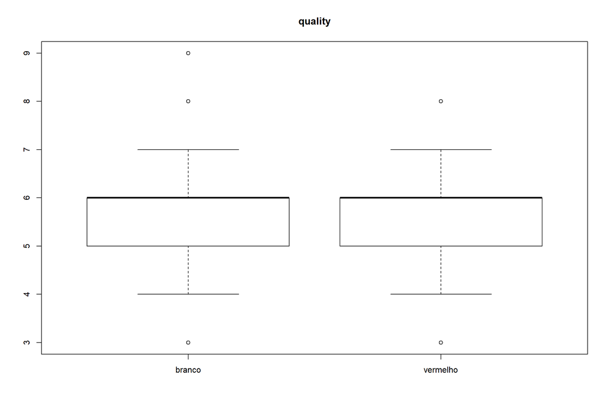

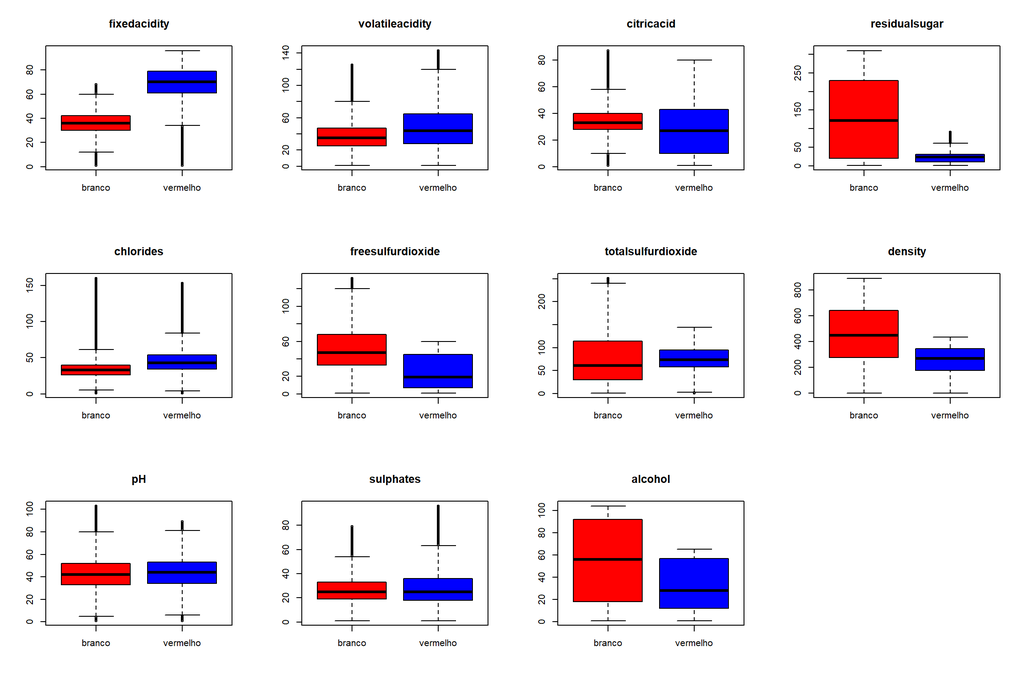

- Correlação Entre os valores - Vinho Tinto

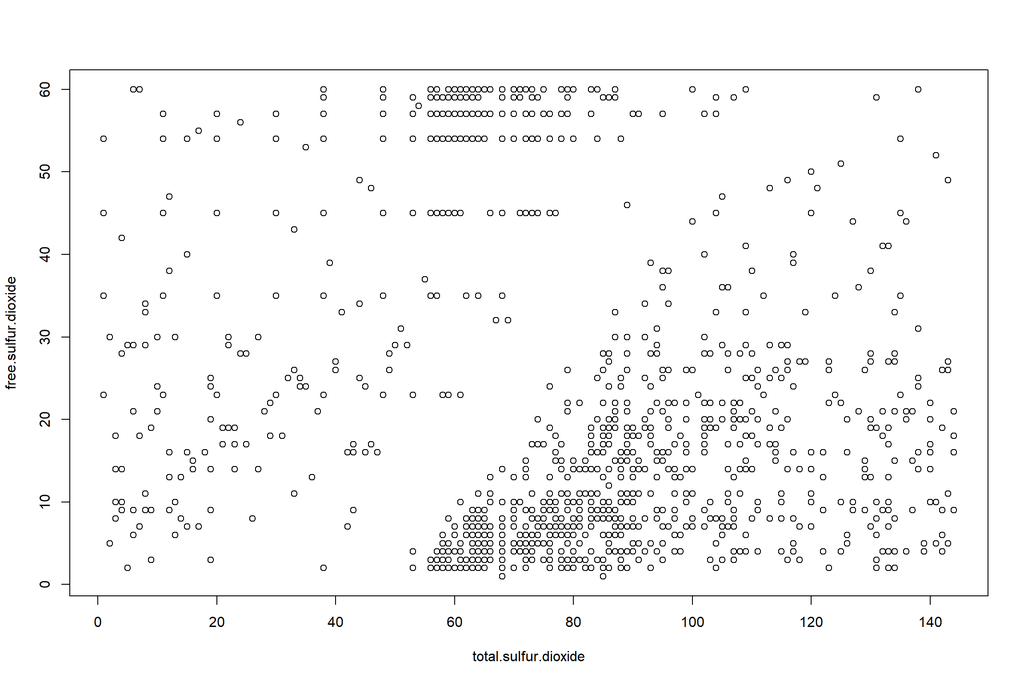

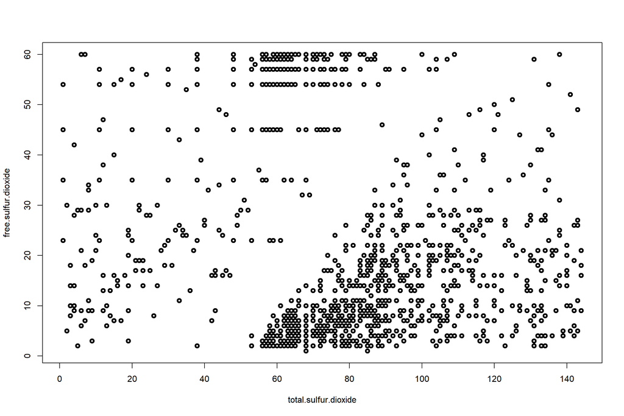

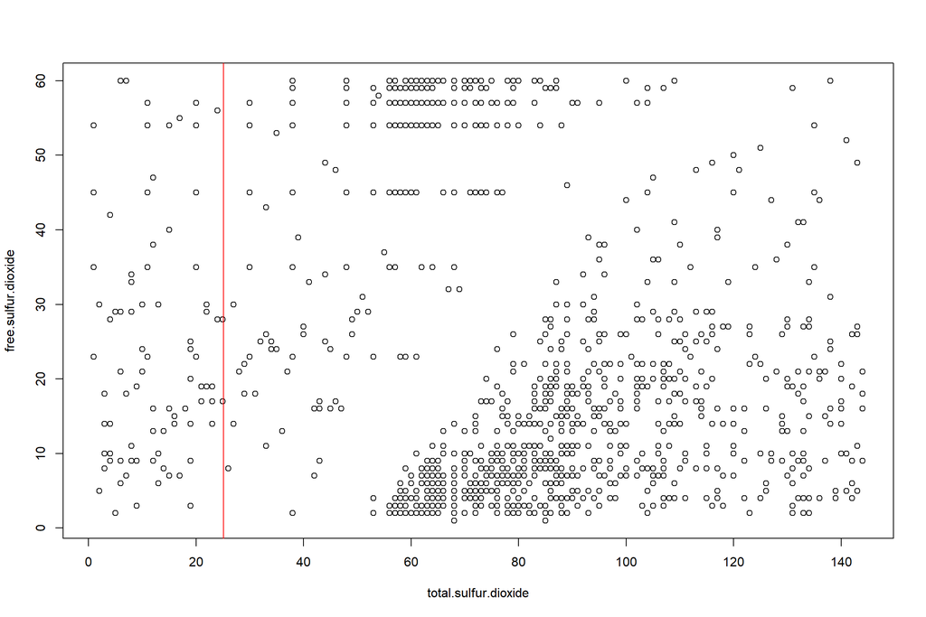

- Correlação Entre os valores - Vinho Branco

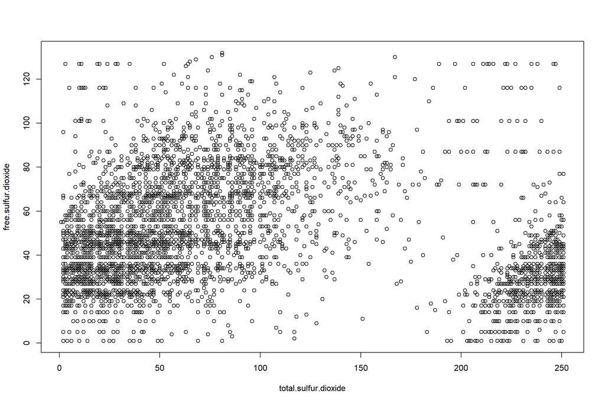

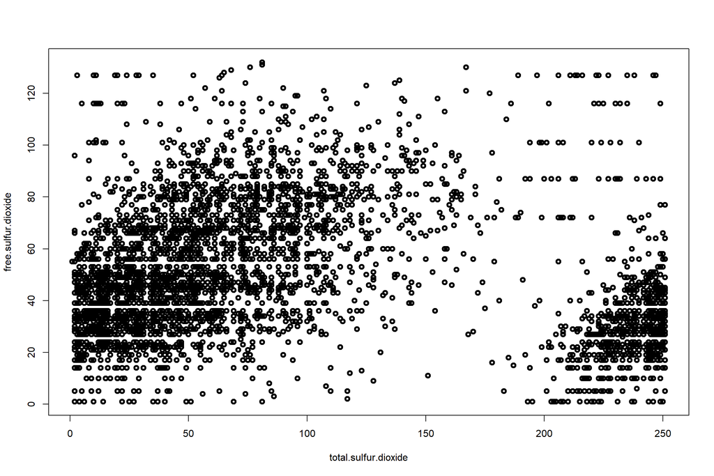

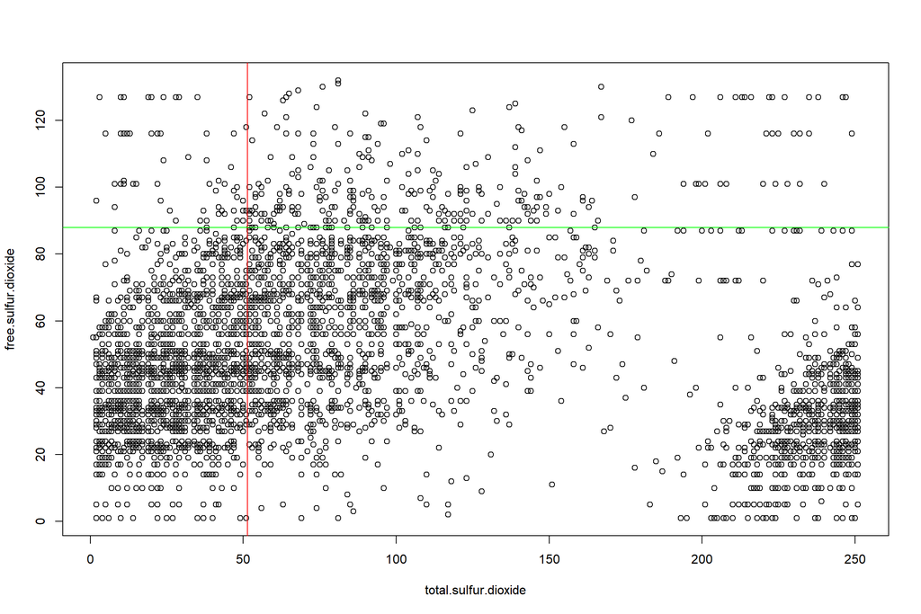

Avaliar se a análise será feita com os dois tipos de vinhos juntos ou se separaria por tipo para analisá-los.  No fechamento desta etapa colocar qual a opção seguirá sobre os tipos de vinhos , sobre os outliers (caso tenha) e o uso de Componentes Principais

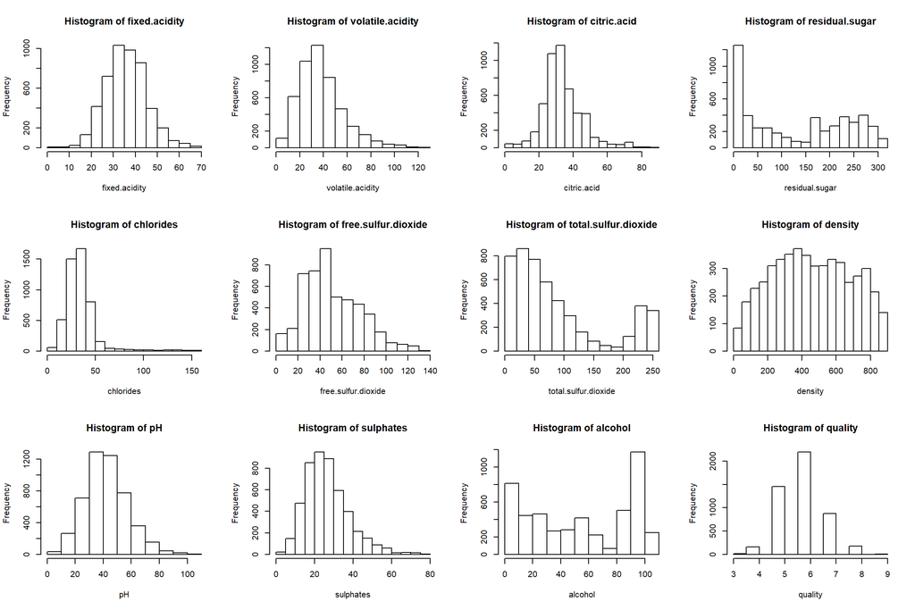

```
##                      quality fixed.acidity volatile.acidity citric.acid
## quality                1.000        -0.093           -0.191      -0.009
## fixed.acidity         -0.093         1.000           -0.032       0.277
## volatile.acidity      -0.191        -0.032            1.000      -0.154
## citric.acid           -0.009         0.277           -0.154       1.000
## residual.sugar         0.038        -0.033            0.111      -0.061
## chlorides             -0.236         0.038            0.061       0.115
## free.sulfur.dioxide   -0.066        -0.019           -0.042       0.104
## total.sulfur.dioxide  -0.027         0.010            0.035      -0.017
## density               -0.329         0.263            0.007       0.146
## pH                     0.100        -0.409           -0.035      -0.167
## sulphates              0.053        -0.020           -0.038       0.065
## alcohol               -0.154        -0.015            0.133       0.055
##                      residual.sugar chlorides free.sulfur.dioxide
## quality                       0.038    -0.236              -0.066
## fixed.acidity                -0.033     0.038              -0.019
## volatile.acidity              0.111     0.061              -0.042
## citric.acid                  -0.061     0.115               0.104
## residual.sugar                1.000    -0.019               0.031
## chlorides                    -0.019     1.000               0.103
## free.sulfur.dioxide           0.031     0.103               1.000
## total.sulfur.dioxide         -0.061    -0.052              -0.089
## density                       0.126     0.320               0.274
## pH                           -0.009    -0.089              -0.033
## sulphates                    -0.043     0.022               0.029
## alcohol                       0.047     0.239               0.153
##                      total.sulfur.dioxide density     pH sulphates alcohol
## quality                            -0.027  -0.329  0.100     0.053  -0.154
## fixed.acidity                       0.010   0.263 -0.409    -0.020  -0.015
## volatile.acidity                    0.035   0.007 -0.035    -0.038   0.133
## citric.acid                        -0.017   0.146 -0.167     0.065   0.055
## residual.sugar                     -0.061   0.126 -0.009    -0.043   0.047
## chlorides                          -0.052   0.320 -0.089     0.022   0.239
## free.sulfur.dioxide                -0.089   0.274 -0.033     0.029   0.153
## total.sulfur.dioxide                1.000  -0.126 -0.053    -0.019  -0.005
## density                            -0.126   1.000 -0.095     0.070   0.378
## pH                                 -0.053  -0.095  1.000     0.157  -0.160
## sulphates                          -0.019   0.070  0.157     1.000  -0.029
## alcohol                            -0.005   0.378 -0.160    -0.029   1.000
```

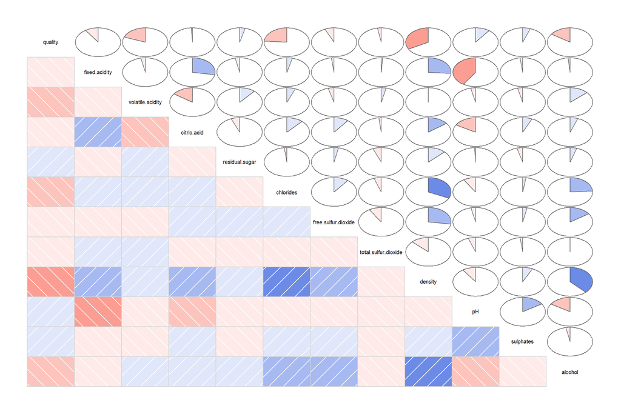

2. Algoritmos para explicar a variável “Quality” O que cada modelo gerou de resultados?

```
##
##     branco vermelho
##   3     20       10
##   4    163       53
##   5   1457      681
##   6   2198      638
##   7    880      199
##   8    175       18
##   9      5        0
```

```
##
##     branco vermelho
##   3     20       10
##   4    163       53
##   5   1457      681
##   6   2198      638
##   7    880      199
##   8    175       18
##   9      5        0
```

> Modelo de *Regressão Linear*:

Regressão linear é uma equação para se estimar a condicional (valor esperado) de uma variável y, dados os valores de algumas outras variáveis x. A regressão, em geral, tem como objectivo tratar de um valor que não se consegue estimar inicialmente.

A regressão linear é chamada “linear” porque se considera que a relação da resposta às variáveis é uma função linear de alguns parâmetros. Os modelos de regressão que não são uma função linear dos parâmetros se chamam modelos de regressão não-linear. Sendo uma das primeiras formas de análise regressiva a ser estudada rigorosamente, e usada extensamente em aplicações práticas. Isso acontece porque modelos que dependem de forma linear dos seus parâmetros desconhecidos, são mais fáceis de ajustar que os modelos não-lineares aos seus parâmetros, e porque as propriedades estatísticas dos estimadores resultantes são fáceis de determinar.

Modelos de regressão linear são frequentemente ajustados usando a abordagem dos mínimos quadrados, mas que também pode ser montada de outras maneiras, tal como minimizando a “falta de ajuste” em alguma outra norma (com menos desvios absolutos de regressão), ou através da minimização de uma penalização da versão dos mínimos quadrados. Por outro lado, a abordagem de mínimos quadrados pode ser utilizado para ajustar a modelos que não são modelos lineares. Assim, embora os termos “mínimos quadrados” e “modelo linear” estejam intimamente ligados, eles não são sinônimos.

- Variável dependente: **Qualidade do Vinho (quality)**
- Variáveis independentes: **Valores de Álcool (alcohol)** e **pH (pH)** do vinho

```
##
## Call:
## lm(formula = quality ~ alcohol + pH)
##
## Residuals:
##      Min       1Q   Median       3Q      Max
## -3.15042 -0.71492  0.03722  0.31700  3.10174
##
## Coefficients:
##               Estimate Std. Error t value Pr(>|t|)
## (Intercept)  5.8778219  0.0452543 129.884  < 2e-16 ***
## alcohol     -0.0035241  0.0003543  -9.947  < 2e-16 ***
## pH           0.0045271  0.0008386   5.399 7.03e-08 ***
## ---
## Signif. codes:  0 '***' 0.001 '**' 0.01 '*' 0.05 '.' 0.1 ' ' 1
##
## Residual standard error: 0.8726 on 4895 degrees of freedom
## Multiple R-squared:  0.02955,    Adjusted R-squared:  0.02915
## F-statistic: 74.52 on 2 and 4895 DF,  p-value: < 2.2e-16
```

```
## [1] 0.8723665
```

```
## [1] 0.8855482
```

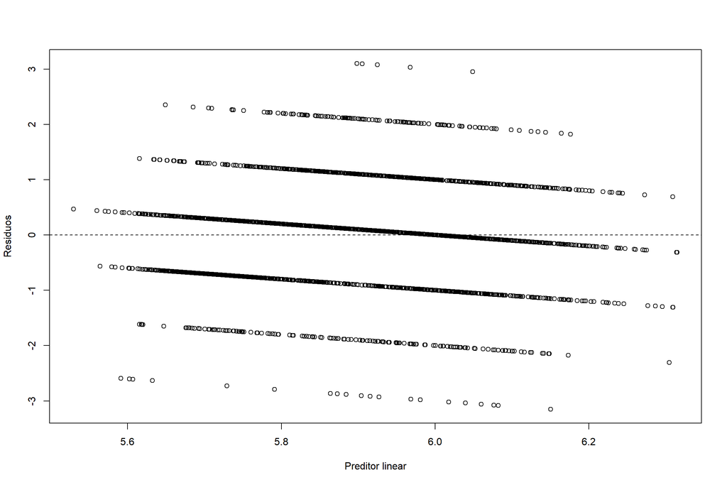

> Modelo de *Árvore de Regressão*:

Uma árvore de regressão é idêntica a uma árvore de decisão porque também é formada por um conjunto de nós de decisão, perguntas, mas o resultado, em vez de uma categoria, é um escalar (número que pertence a uma escala).

As árvores de regressão são usadas quando a variável dependente é contínua. As árvores de classificação são usadas quando a variável dependente é categórica.

Neste tipo de árvore para análise o valor obtido pelos nós de término nos dados de treinamento é o valor médio das suas observações. Assim, a uma nova observação de dados atribui-se o valor médio correspondente.

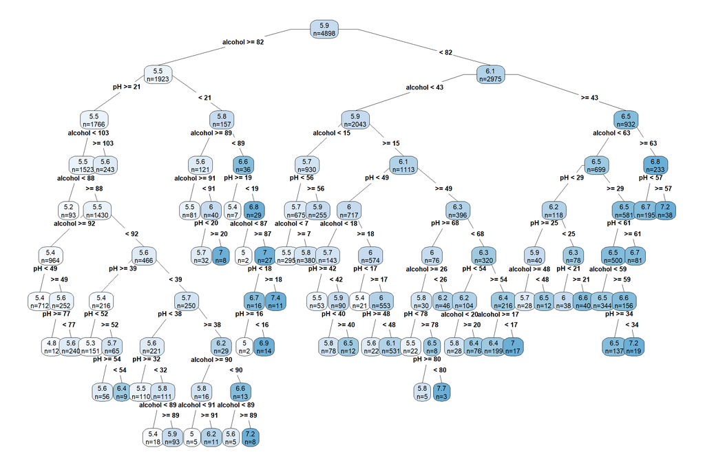

```
##  Named num [1:4898] 5.39 5.6 5.53 5.65 5.65 ...
##  - attr(*, "names")= chr [1:4898] "1" "2" "3" "4" ...
```

```
## [1] 0.7474812
```

```
## [1] 0.8855482
```

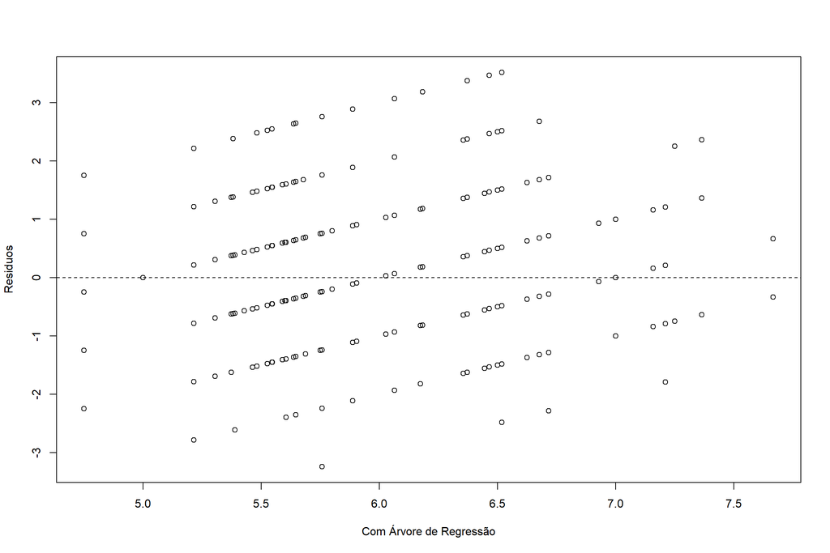

> Modelo de *Árvore de Decisão*:

Um modelo de aprendizagem de árvore de decisão é uma classe de métodos estatísticos que prevê uma variável de meta usando uma ou mais variáveis que tenham influência na variável de meta e que, muitas vezes, são chamadas de variáveis de previsão. A previsão é feita pela criação de um conjunto de regras de divisão de “inclusão-implicação” que otimizam um critério. Os critérios usados para formar essas regras dependem da natureza da variável de meta. Se a variável de meta identificar a associação em um conjunto de categorias, uma árvore de classificação será criada com base na maximização da “pureza” em cada divisão baseada no coeficiente Gini ou em um índice de informações baseado em entropia. Se a variável de meta for uma variável contínua, uma árvore de regressão será criada usando os critérios de divisão para minimizar a soma dos erros ao quadrado em cada divisão.

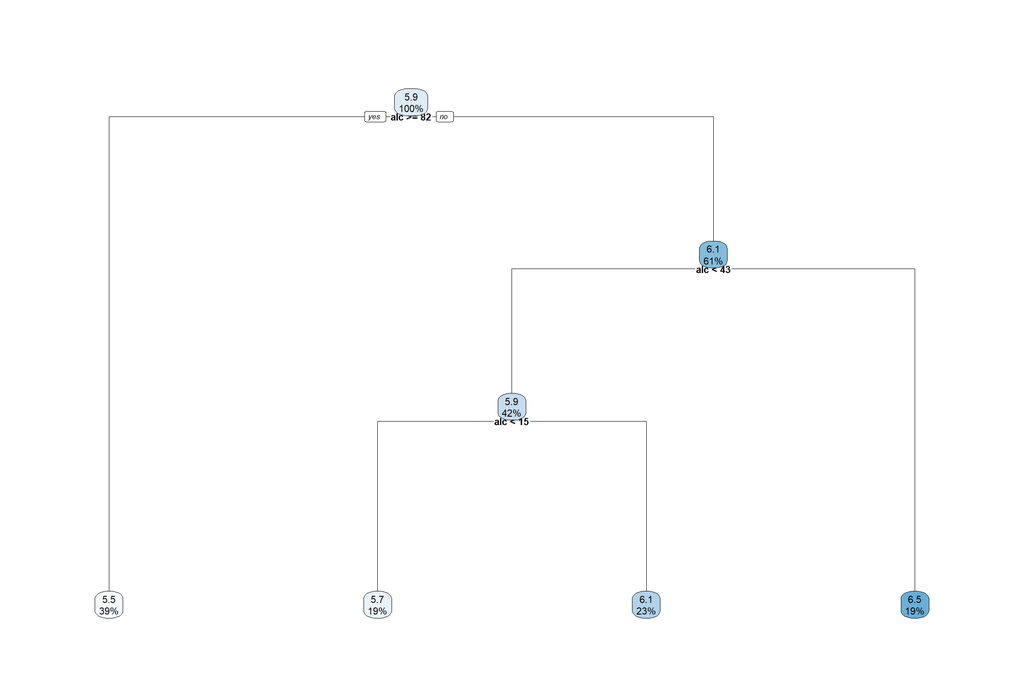

```
## preds_cat
## 5.51222048881955 5.71935483870968 6.07996406109614 6.54935622317597
##             1923              930             1113              932
```

```
##        1        2        3        4        5        6
## 5.512220 5.512220 5.719355 5.512220 5.512220 5.719355
```

```
##        Vinho.previsto.com.modelo
## quality 5.51222048881955 5.71935483870968 6.07996406109614
##       3                8                4                6
##       4               73               47               33
##       5              935              283              195
##       6              762              481              554
##       7              123              103              282
##       8               22               11               43
##       9                0                1                0
##        Vinho.previsto.com.modelo
## quality 6.54935622317597
##       3                2
##       4               10
##       5               44
##       6              401
##       7              372
##       8               99
##       9                4
```

```
## [1] 0.1329114
```

```
## [1] 0.8670886
```

[figure not shown]

[figure not shown]

A regressão logística é uma técnica estatística que tem como objetivo produzir, a partir de um conjunto de observações, um modelo que permita a predição de valores tomados por uma variável categórica, frequentemente binária, a partir de uma série de variáveis explicativas contínuas e/ou binárias.

O êxito da regressão logística assenta sobretudo nas numerosas ferramentas que permitem interpretar de modo aprofundado os resultados obtidos.

Em comparação com as técnicas conhecidas em regressão, em especial a regressão linear, a regressão logística distingue-se essencialmente pelo facto de a variável resposta ser categórica.

Enquanto método de predição para variáveis categóricas, a regressão logística é comparável às técnicas supervisionadas propostas em aprendizagem automática (árvores de decisão, redes neurais, etc.), ou ainda a análise discriminante preditiva em estatística exploratória. É possível de as colocar em concorrência para escolha do modelo mais adaptado para um certo problema preditivo a resolver.

A regressão logística é amplamente usada em ciências médicas e sociais, e tem outras denominações, como modelo logístico, modelo logit, e classificador de máxima entropia.

```
##
## Call:
## glm(formula = quality ~ alcohol + pH, family = gaussian, data = white_wine_quality)
##
## Deviance Residuals:
##      Min        1Q    Median        3Q       Max
## -3.15042  -0.71492   0.03722   0.31700   3.10174
##
## Coefficients:
##               Estimate Std. Error t value Pr(>|t|)
## (Intercept)  5.8778219  0.0452543 129.884  < 2e-16 ***
## alcohol     -0.0035241  0.0003543  -9.947  < 2e-16 ***
## pH           0.0045271  0.0008386   5.399 7.03e-08 ***
## ---
## Signif. codes:  0 '***' 0.001 '**' 0.01 '*' 0.05 '.' 0.1 ' ' 1
##
## (Dispersion parameter for gaussian family taken to be 0.7614897)
##
##     Null deviance: 3841.0  on 4897  degrees of freedom
## Residual deviance: 3727.5  on 4895  degrees of freedom
## AIC: 12570
##
## Number of Fisher Scoring iterations: 2
```

```
##    Min. 1st Qu.  Median    Mean 3rd Qu.    Max.
##   5.530   5.742   5.875   5.878   6.002   6.315
```

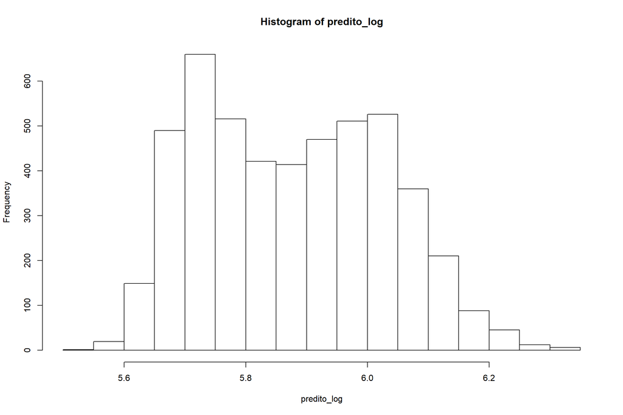

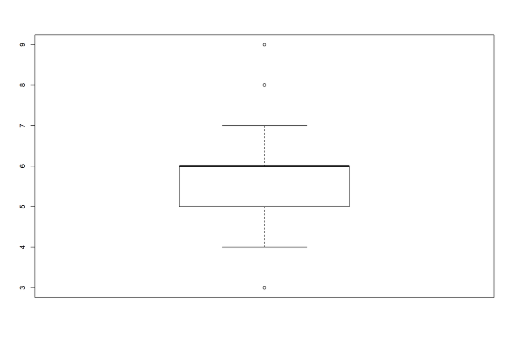

```
##        white_wine_quality$fx_predito
## quality [3,9)
##       3    20
##       4   163
##       5  1457
##       6  2198
##       7   880
##       8   175
##       9     5
```

```
## [1] 0.004083299
```

```
##            quality
## fx_predito1    3    4    5    6    7    8    9
##       [5,6)   14  119 1155 1578  647  134    4
##       [6,7)    6   44  302  620  233   41    1
```

```
##            quality
## fx_predito1         3         4         5         6         7         8
##       [5,6) 0.7000000 0.7300613 0.7927248 0.7179254 0.7352273 0.7657143
##       [6,7) 0.3000000 0.2699387 0.2072752 0.2820746 0.2647727 0.2342857
##            quality
## fx_predito1         9
##       [5,6) 0.8000000
##       [6,7) 0.2000000
```

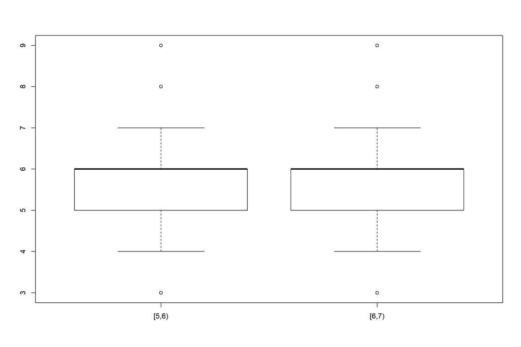

> Comparação entre os modelos:

Utilizando as métricas adequadas para comparação de modelos façam um resumo sobre a qualidade dos modelos e indiquem qual o modelo/técnica que vocês recomendariam

> Resumo das técnicas utilizadas

A escolha da técnica estatística pode não ser lá a decisão mais crucial para que um modelo preditivo seja bom, mas saber escolher entre uma técnica e outra pode trazer ganhos expressivos e até ser determinantes no sucesso das previsões. Cada técnica apresenta benefícios e limitações diferentes.

Das técnicas utilizadas, a que pudemos classificar melhor a análise foi a **árvore de Decisão**, justamente pela sua fácil interpretação.

> Recomendação

4. Nesta atividade usamos somente algumas técnicas supervisionadas,
1. quais outras técnicas supervisionadas vocês indicariam como adequadas para esta análise?
2. e, das técnicas Não Supervisionadas, quais?

O modelo de **Clusterização** seria uma ótima abordagem.

A Aprendizagem não supervisionada, por outro lado, nos permite abordar problemas com pouca ou nenhuma idéia do que nossos resultados deve ser aparentar. Podemos derivar estrutura de dados onde nós não necessariamente saberiamos o efeito das variáveis. Podemos derivar essa estrutura, agrupando os dados com base em relações entre as variáveis nos dados. Também pode ser usada para reduzir o número de dimensões em um conjunto de dados para concentrar somente nos atributos mais úteis, ou para detectar tendências. Com aprendizagem não supervisionada não há feedback com base nos resultados da previsão.